# Red Wine Dataset EDA

# 红酒质量分析 by ATango, 2018年8月5日

# 1 Summary of the Dataset

## 1.1 红酒数据集

选取了Uda项目提供的红酒质量数据集。 数据来源：Paulo Cortez (Univ. Minho)等； 相关论文：Modeling wine preferences by data mining from physicochemical properties.

依据项目提供的数据描述，该**数据集共包括1599条数据、11个输入变量、1个输出变量**，其中个别属性相关。 对此，我对该数据集进行了验证，如下。

验证结果与数据描述基本一致，只在变量个数上略有差异。 数据集多了一个X变量，应该是ID，应可以忽略。

## 1.2 变量及其解释

依据项目提供的数据描述，各变量的涵义如下。 11个输入变量： 1 - 酒石酸，fixed acidity (tartaric acid - g / dm^3) 2 - 挥发性酸，volatile acidity (acetic acid - g / dm^3) 3 - 柠檬酸，citric acid (g / dm^3) 4 - 残留糖分，residual sugar (g / dm^3) 5 - 盐，chlorides (sodium chloride - g / dm^3 6 - SO2游离量，free sulfur dioxide (mg / dm^3) 7 - SO2总量，total sulfur dioxide (mg / dm^3) 8 - 密度，density (g / cm^3) 9 - PH值，pH 10 - 硫酸盐，sulphates (potassium sulphate - g / dm3) 11 - 酒精，alcohol (% by volume) 1个输出变量： 12 - 质量，quality (score between 0 and 10)

变量描述： 1 - 酒石酸度：大多数与葡萄酒有关的酸或固定或非挥发性的酸（不易蒸发） 2 - 挥发性酸度：葡萄酒中醋酸的含量过高会导致令人不快的醋味 3 - 柠檬酸：少量发现，柠檬酸可以为葡萄酒增添“新鲜感”和风味 4 - 残留糖分：发酵停止后剩余的糖量，很少能找到低于1克/升的葡萄酒，超过45克/升的葡萄酒被认为是甜的 5 - 氯化物：葡萄酒中的盐量 6 - SO2游离量：游离形式的二氧化硫在分子SO2（作为溶解气体）和亚硫酸氢根离子之间存在平衡;它可以防止微生物生长和葡萄酒的氧化 7 - SO2总量：游离和结合形式的SO2的量;在低浓度下，SO2在葡萄酒中几乎检测不到，但在游离SO2浓度超过50ppm时，SO2在葡萄酒的味道和味道中变得明显 8 - 密度：与水的密度接近，取决与酒精和糖含量的比例 9 - pH：描述葡萄酒的酸度或碱度如何从0（非常酸性）到14（非常碱性）; 大多数葡萄酒的pH值在3-4之间 10 - 硫酸盐：一种葡萄酒添加剂，可以产生二氧化硫气体（SO2）水平，起到抗菌和抗氧化剂的作用 11 - 酒精：酒的酒精含量百分比 12 - 质量（0到10之间的分数）

## 1.3 各指标的统计量

```
'data.frame':   1599 obs. of  13 variables:
 $ X                   : int  1 2 3 4 5 6 7 8 9 10 ...
 $ fixed.acidity       : num  7.4 7.8 7.8 11.2 7.4 7.4 7.9 7.3 7.8 7.5 ...
 $ volatile.acidity    : num  0.7 0.88 0.76 0.28 0.7 0.66 0.6 0.65 0.58 0.5 ...
 $ citric.acid         : num  0 0 0.04 0.56 0 0 0.06 0 0.02 0.36 ...
 $ residual.sugar      : num  1.9 2.6 2.3 1.9 1.9 1.8 1.6 1.2 2 6.1 ...
 $ chlorides           : num  0.076 0.098 0.092 0.075 0.076 0.075 0.069 0.065 0.073 0.071 ...
 $ free.sulfur.dioxide : num  11 25 15 17 11 13 15 15 9 17 ...
 $ total.sulfur.dioxide: num  34 67 54 60 34 40 59 21 18 102 ...
 $ density             : num  0.998 0.997 0.997 0.998 0.998 ...
 $ pH                  : num  3.51 3.2 3.26 3.16 3.51 3.51 3.3 3.39 3.36 3.35 ...
 $ sulphates           : num  0.56 0.68 0.65 0.58 0.56 0.56 0.46 0.47 0.57 0.8 ...
 $ alcohol             : num  9.4 9.8 9.8 9.8 9.4 9.4 9.4 10 9.5 10.5 ...
 $ quality             : int  5 5 5 6 5 5 5 7 7 5 ...
```

目视来看，大部分指标的**值比较小、范围比较集中**，说明这些指标都相当敏感。 也有例外，SO2无论是游离态、还是总量，分布范围都比较大，**可能在SO2方面存在一些异常现象**。

而最关心的质量分，中值为及格分6分，均分为5.6分，最低3分，最高8分。即普通酒比较多，**可以尝试专门针对高、低分进行分析**。

## 1.4 初始问题：质量由什么决定？

1. 这些变量是如何分布的？有什么特征？
2. 红酒的质量由哪些关键因素决定？
3. 依据关键因素，建立预测模型？即如何选出“好酒”？（后来发现效果一般，关键的因素相关性过低，尝试提高相关性，但数据量较少，就没继续做了。）

# 2 Univariate Plots Section

## 2.1 Output：质量分的分布

与前面的猜测一致，大部分质量酒的质量是5-6分，少量的7分，3、4、8分都极其少。

**考虑到打分都是整数分，可以转换为factor。**新增quality_level，对应质量分从3-8，数字越高，红酒的质量越好。

|  | X | fixed.acidity | volatile.acidity | citric.acid | residual.sugar | chlorides | free.sulfur.dioxide | total.sulfur.dioxide | density | pH | sulphates | alcohol | quality |
| --- | --- | --- | --- | --- | --- | --- | --- | --- | --- | --- | --- | --- | --- |
| 1 | 1 | 7.4 | 0.70 | 0.00 | 1.9 | 0.076 | 11 | 34 | 0.9978 | 3.51 | 0.56 | 9.4 | 5 |
| 2 | 2 | 7.8 | 0.88 | 0.00 | 2.6 | 0.098 | 25 | 67 | 0.9968 | 3.20 | 0.68 | 9.8 | 5 |
| 3 | 3 | 7.8 | 0.76 | 0.04 | 2.3 | 0.092 | 15 | 54 | 0.9970 | 3.26 | 0.65 | 9.8 | 5 |
| 4 | 4 | 11.2 | 0.28 | 0.56 | 1.9 | 0.075 | 17 | 60 | 0.9980 | 3.16 | 0.58 | 9.8 | 6 |
| 5 | 5 | 7.4 | 0.70 | 0.00 | 1.9 | 0.076 | 11 | 34 | 0.9978 | 3.51 | 0.56 | 9.4 | 5 |
| 6 | 6 | 7.4 | 0.66 | 0.00 | 1.8 | 0.075 | 13 | 40 | 0.9978 | 3.51 | 0.56 | 9.4 | 5 |

## 2.2 Input：各因素的分布

```
       X          fixed.acidity   volatile.acidity  citric.acid    residual.sugar     chlorides
 Min.   :   1.0   Min.   : 4.60   Min.   :0.1200   Min.   :0.000   Min.   : 0.900   Min.   :0.01200
 1st Qu.: 400.5   1st Qu.: 7.10   1st Qu.:0.3900   1st Qu.:0.090   1st Qu.: 1.900   1st Qu.:0.07000
 Median : 800.0   Median : 7.90   Median :0.5200   Median :0.260   Median : 2.200   Median :0.07900
 Mean   : 800.0   Mean   : 8.32   Mean   :0.5278   Mean   :0.271   Mean   : 2.539   Mean   :0.08747
 3rd Qu.:1199.5   3rd Qu.: 9.20   3rd Qu.:0.6400   3rd Qu.:0.420   3rd Qu.: 2.600   3rd Qu.:0.09000
 Max.   :1599.0   Max.   :15.90   Max.   :1.5800   Max.   :1.000   Max.   :15.500   Max.   :0.61100
 free.sulfur.dioxide total.sulfur.dioxide    density             pH          sulphates         alcohol
 Min.   : 1.00       Min.   :  6.00       Min.   :0.9901   Min.   :2.740   Min.   :0.3300   Min.   : 8.40
 1st Qu.: 7.00       1st Qu.: 22.00       1st Qu.:0.9956   1st Qu.:3.210   1st Qu.:0.5500   1st Qu.: 9.50
 Median :14.00       Median : 38.00       Median :0.9968   Median :3.310   Median :0.6200   Median :10.20
 Mean   :15.87       Mean   : 46.47       Mean   :0.9967   Mean   :3.311   Mean   :0.6581   Mean   :10.42
 3rd Qu.:21.00       3rd Qu.: 62.00       3rd Qu.:0.9978   3rd Qu.:3.400   3rd Qu.:0.7300   3rd Qu.:11.10
 Max.   :72.00       Max.   :289.00       Max.   :1.0037   Max.   :4.010   Max.   :2.0000   Max.   :14.90
    quality
 Min.   :3.000
 1st Qu.:5.000
 Median :6.000
 Mean   :5.636
 3rd Qu.:6.000
 Max.   :8.000
```

注意到12以上分布极少（单位见数据描述。考虑到单位并不影响分析过程，本报告的分析部分全部略去单位），可重点考察此部分与质量关系，看看此特性究竟是“极品”还是“垃圾”。后面类似。

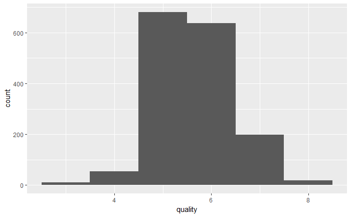

0.9以后分布极少。

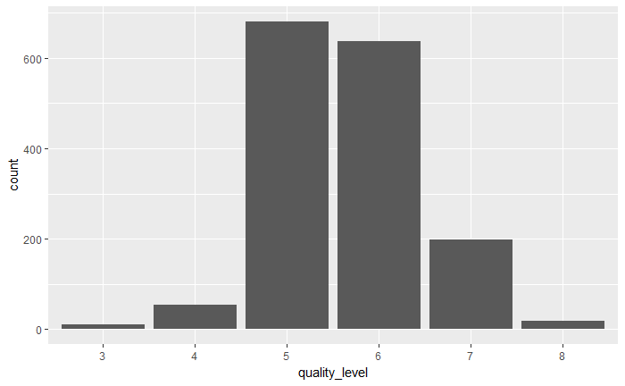

**柠檬酸：**如果不考虑0，几乎是均匀分布，但**在0、0.25、0.5有明显的突起**。0.5以后则开始明显降低。 0.7以后分布极少。

尝试加上辅助线。

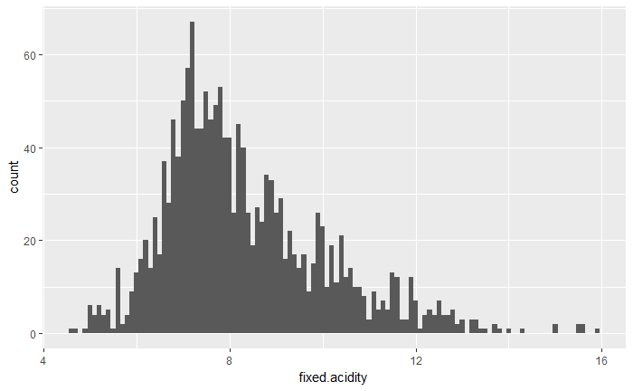

尝试后用密度估计辅助可视化。由图可见，**柠檬酸**分布在0.5以下的分布相对均匀，0.5以后快速下降，0.75以后几乎为0

考虑到酸度的重要性，先尝试将数据集中的fixed.acidity、volatile.acidity、citric.acid加和，得到“总酸”。

但后面做相关性分析的时候发现，挥发性酸和质量负相关。因此，又调整“总酸”，用酒石酸和柠檬酸的和。

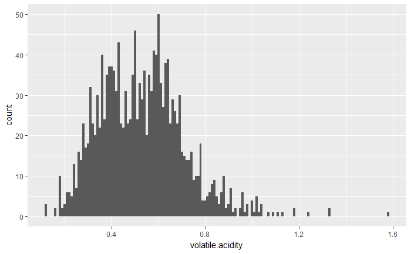

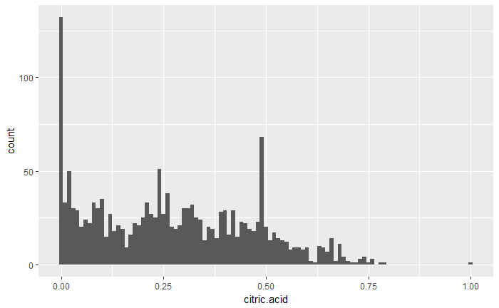

**残留糖分：**分布很集中。但在4、6、8附近有少量的集聚分布。

5以后分布较少。

尝试对集中部分放大显示。

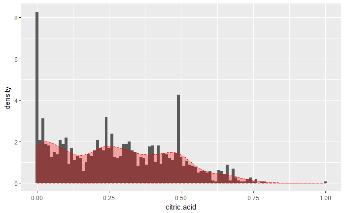

上图表明，含糖量基本为正态分布。均值在2左右。

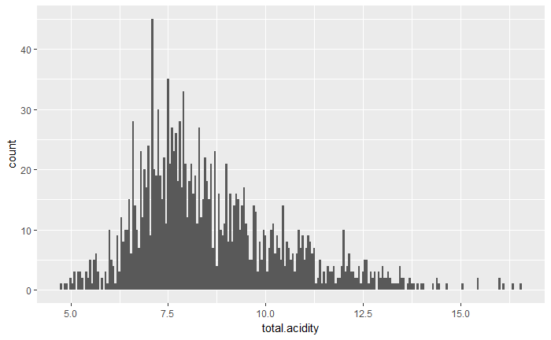

**盐份：**分布与残留糖分分布极为类似，但分布更加集中，只出现了极少量的异常值。

同样尝试对集中部分放大显示。

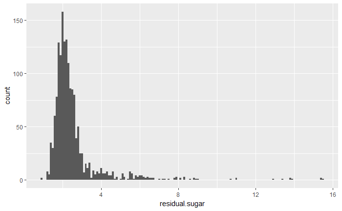

上图表明，含盐量基本为正态分布。均值在0.075左右。

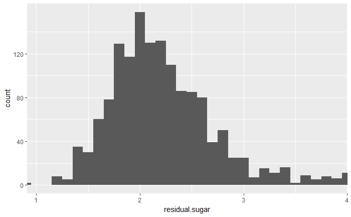

**SO2游离量：**分布类似长尾分布。

尝试转换为log_X

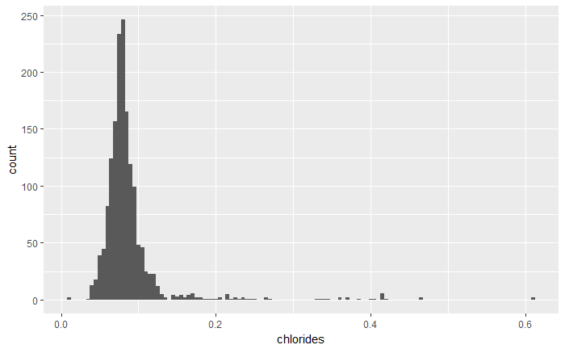

尝试后发现，SO2游离量勉强近似为正态分布。

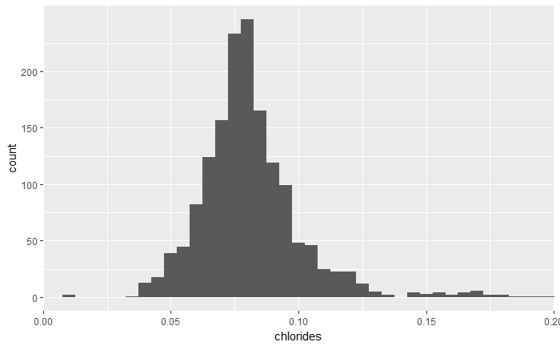

**SO2总量：**与SO2游离量的分布相似，也类似长尾分布。

同样尝试转换为log_X

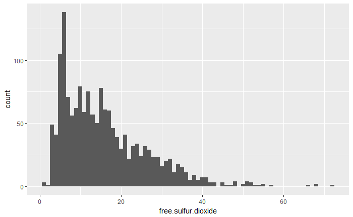

尝试后发现，SO2总量呈较为明显的正态分布。

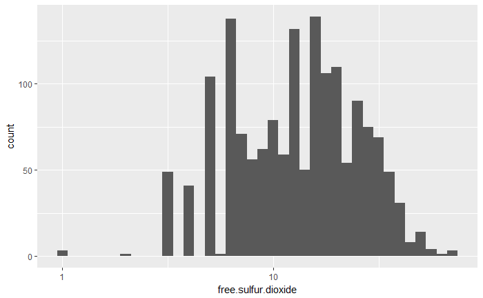

显然，**密度**极其敏感，总体呈正态分布。中值大概在0.997左右。

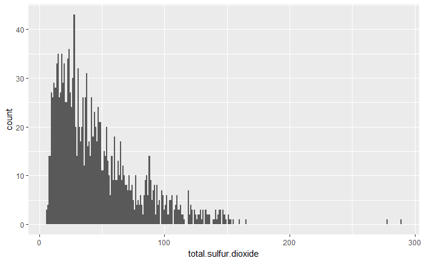

又一个敏感的指标，**pH值**总体也是呈正态分布。均值大概在3.3左右，表明红酒呈酸性。显然，该指标与酸度有关。

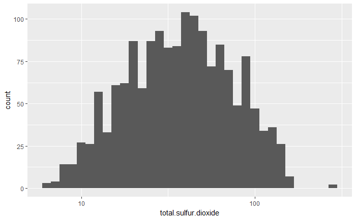

**硫酸盐：**分布呈偏正态分布。均值在0.6左右。1.0以后分布较少。

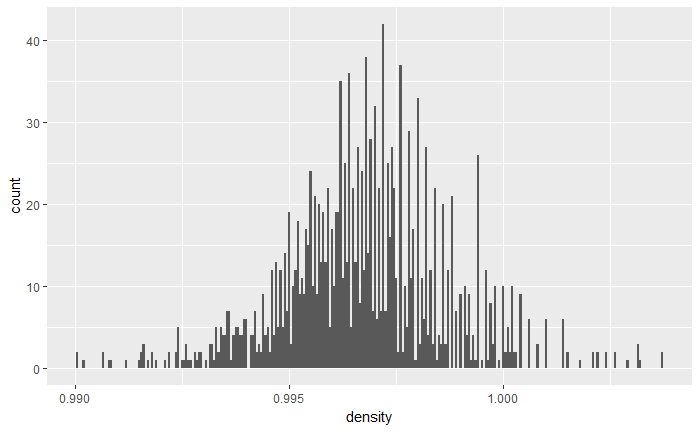

**酒精**含量基本是一个快速上升后逐步下降的分布，不太像长尾分布。

# 3 Univariate Analysis

## 3.1 What is the structure of your dataset?

该**数据集共包括1599条数据、11个输入变量、1个输出输出**。具体如下： Input variables (based on physicochemical tests): 1 - fixed acidity (tartaric acid - g / dm^3) 2 - volatile acidity (acetic acid - g / dm^3) 3 - citric acid (g / dm^3) 4 - residual sugar (g / dm^3) 5 - chlorides (sodium chloride - g / dm^3 6 - free sulfur dioxide (mg / dm^3) 7 - total sulfur dioxide (mg / dm^3) 8 - density (g / cm^3) 9 - pH 10 - sulphates (potassium sulphate - g / dm3) 11 - alcohol (% by volume) Output variable (based on sensory data): 12 - quality (score between 0 and 10)

## 3.2 What is/are the main feature(s) of interest in your dataset?

显然，最重要的是质量分，是最终结果。 其次，就是影响质量分的因素。

通过查阅资料（见参考资料），葡萄酒98%由水和酒精组成，剩下2%的化学物质决定了口感。2%大概有上千种，从已有的文献，往往会分析其中20-60种之多。显然，本项目的数据集，仅有11个指标，有一定差距。尤其是，对“单宁”、香气等的讨论好像十分多，具体不知道是个啥，也不知道是否涵盖在本数据集的指标中。

不过，从现有资料来看，可以将数据集归纳为几个关键影响因素（重要性依次下降）： **一是酸度。**主要是酒石酸，是不挥发性酸的主要构成，某种意义上来说，也可以被认为就是总酸。醋酸、柠檬酸则是作为补充。而ph值是酸度的另一种测量方法。 **二是酒精。**既然是酒，酒精含量就是必须要考虑的。 **三是糖分。**也是影响口感的重要因素。

参考资料： 1. Hopfer, Helene, et al. “Correlating wine quality indicators to chemical and sensory measurements.” Molecules 20.5 (2015): 8453-8483.

2. King, E.S., Stoumen, M., Buscema, F., Hjelmeland, A.K., Ebeler, S.E., Heymann, H., Boulton, R.B., Regional sensory and chemical characteristics of Malbec wines from Mendoza and California, Food Chemistry (2013), doi: http://dx.doi.org/10.1016/j.foodchem.2013.07.085
3. [Taste-Wine-Science](https://cen.acs.org/articles/92/i38/Taste-Wine-Science.html)
4. [追击葡萄酒的头号组成物质：酸_葡萄酒品鉴_红酒世界网](http://www.wine-world.com/culture/pj/20131109211330952)
5. [葡萄酒酸度_百度百科](https://baike.baidu.com/item/%E8%91%A1%E8%90%84%E9%85%92%E9%85%B8%E5%BA%A6/12614579?fr=aladdin)
6. [A Simplified View of Chemical Oxidation Mechanisms in Red Wines and the Role of Sulfur Dioxide]http://www.techniquesinhomewinemaking.com/blog/a-simplified-view-of-chemical-oxidation-mechanisms-in-red-wines-and-the-role-of-sulfur-dioxide/
7. [葡萄酒知识——详解葡萄酒酒精度数](https://www.winesou.com/baike/bolan/20180315/124603_1.html)

## 3.3 What other features in the dataset do you think will help support your investigation into your feature(s) of interest?

依据上述参考资料，还有一些因素会影响红葡萄酒的口感： **一是醋酸（挥发性酸）。**该值过高，会影响口感。 **二是SO2。**包括游离量、总量、硫酸盐等，主要是因添加剂而存在，起到抗菌、抗氧化的作用，一般感受不到，但浓度较大时会影响口感。 **三是盐分。**产生机制没太弄清楚，但好像是盐分不太好。

值得一提的是，密度因素，猜测主要是受水、酒精的比例影响。考虑到之前的分析发现，密度十分敏感，根据文献1，还可能受一些元素的影响。此因素应该与红酒酒精度高度相关，应不用重复考虑。

## 3.4 Did you create any new variables from existing variables in the dataset?

是的。 新增quality_level变量。考虑到打分均为整数，因此将qulity转换为factor，便于后续分析不同质量分与其它特征的关系。 新增total.acidity变量。考虑到酸度无疑是数据集中最可能影响红酒质量的因素，将数据集中的fixed.acidity、citric.acid加和，得到总酸。

## 3.5 Of the features you investigated, were there any unusual distributions? Did you perform any operations on the data to tidy, adjust, or change the form of the data? If so, why did you do this?

柠檬酸费的分布不是明显的正态分布或长尾分布，而是在0.5以前均匀分布，同时在0、0.25、0.5有明显的突起，0.5以后则开始明显降低。为描述这一趋势，用geom_density()添加了密度的辅助线，可以更为清晰地看出分布状况。

残余糖分的分布集中在0.9-3之间。为此，用coord_trans(limx = c(0.91, 4))调整了坐标轴，能够放大该部分。盐分也是如此。

# 4 Bivariate Plots Section

## 4.1 绘制散点图矩阵

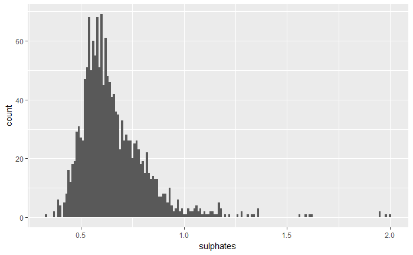

嗯，着实有点难看。

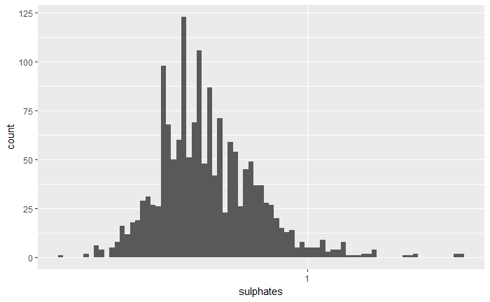

psych包好看不少，而且效率要高得多。

从图上来看，除了酒精相关性为0.48，其它均低于0.4，相关度极低。包括新增加的指标“总酸”，相关性也仅在0.14，基本不相关。

除了质量分以外，密度、ph值和非挥发性酸的相关度较高，均超过0.6。理论上也能说得通，酸的浓度越大越重、ph值越低。

前面根据资料分析，应该关注的一些关键要素，在相关性上表现并不好。

**可能意味着样本不合适。考虑到大多数酒均为“及格酒”，有两种尝试方案：一是排除高分、低分酒，只针对大多数酒；二是只针对特殊的“高分酒”进行分析。**

按大多数可能更适合。因此采取第一方案，等模型建立后，再用全体数据进行验证。**以后有空的适合可以分析下第二方案。**

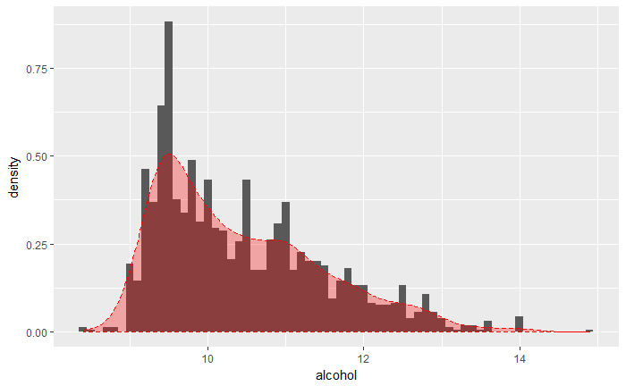

## 4.2 探索“酸”方面的影响

### （1）非挥发性酸

尝试用箱线图表达，能反映数据的集中情况。但是与散点图相比，不能反映数量。

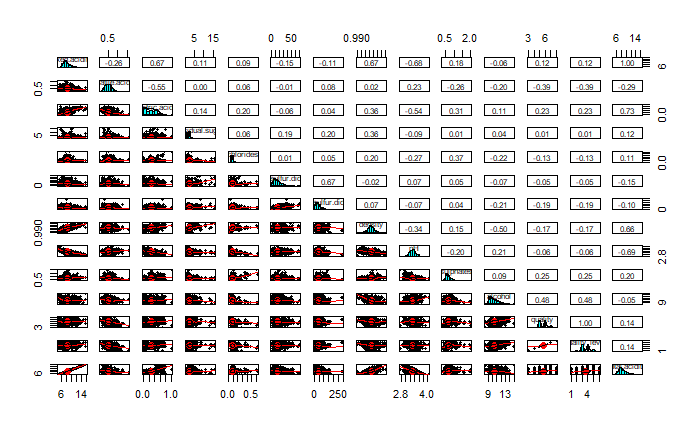

显然，红酒的质量分越高，非挥发性酸（酒石酸）的浓度越高。

为了即反映数量分布、又反映集中情况，尝试将两种可视化方式叠加。

虽然图的信息量较大，但作为数据探索，感觉还是比较合适的。

[output not shown]

### （2）柠檬酸

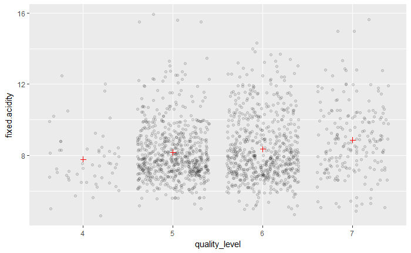

这样的可视化方式，显然能够观察更多细节：

（1）如果只看均值或种植，柠檬酸的影响更明显，质量高的红酒意味着柠檬酸不会低。几乎可以判断，0.1以下，得分就很难超过4。

（2）但如果看散点就会发现，质量分为5、6的红酒中，不少的柠檬算都低于0.1，尤其是很多为0。

**可以考虑舍去柠檬酸较低的top 1%。**

### （3）挥发性酸

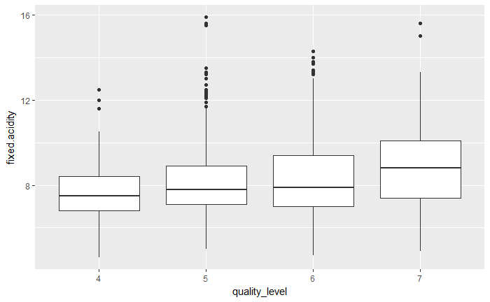

### （4）“总酸”

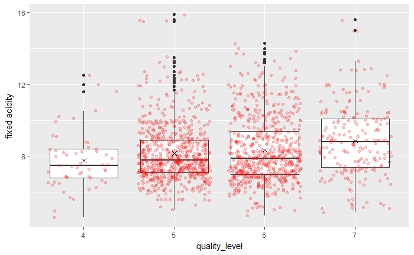

看来效果并不好。

考虑用“柠檬酸 - 挥发性酸”尝试下。这两种酸都有相对较好的相关性，新变量取名key.acidity

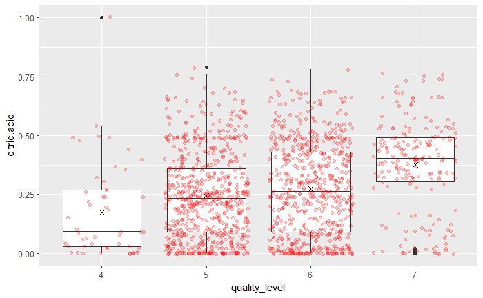

虽然有些改进，但还是不如只用挥发性酸的效果好。

### （5）小结

只采用挥发性酸。

## 4.3 探索SO2方面的影响

### （1）游离态SO2

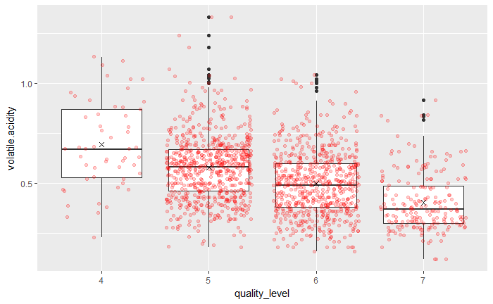

几乎毫无规律。

考虑到前面分析，SO2需要取log，再尝试下。

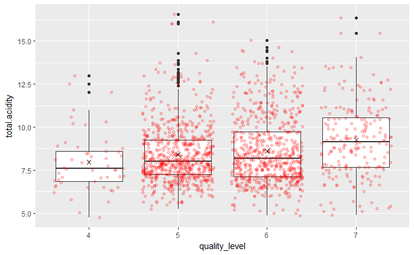

几乎没有任何改进。

### （2）总量SO2

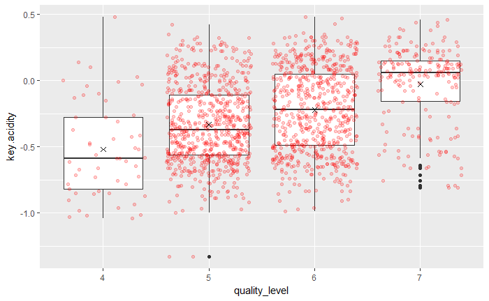

### （3）硫酸盐

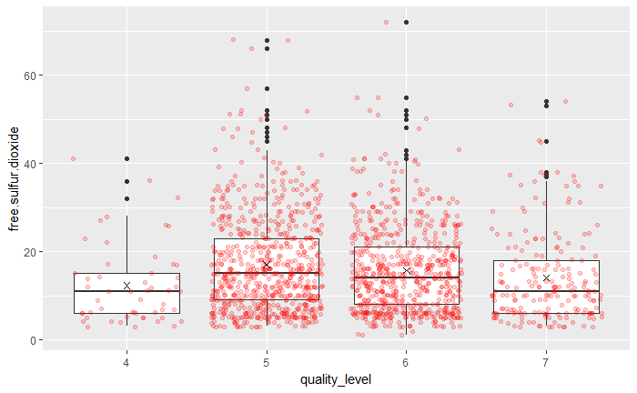

### （4）小结

只采用取log后的硫酸盐。

## 4.3 探索酒精方面的影响

之前的分析中，酒精是相关性最高的。

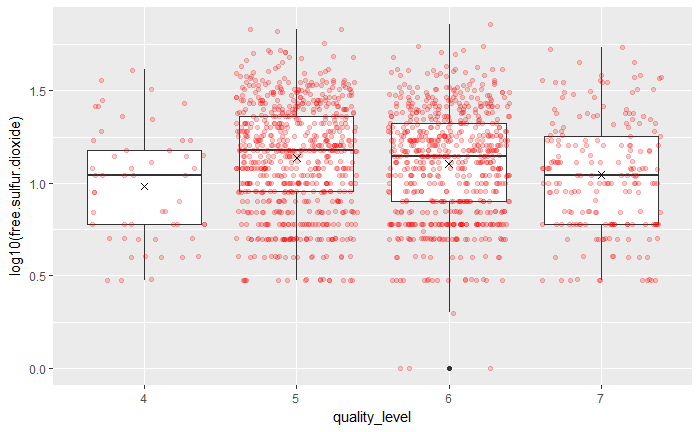

## 4.4 一个合理的猜测

分析到现在，已经感觉到样本数量不够带来的限制。导致很多分析无法合理解释。

做这个项目做到心累。

据此，我猜测存在这样一种打分方式：专家在打分前心里已经有了5或6分的基本预期，再根据口感，进行微调。而且这种微调具有一（hen）定（qiang）的随机性。

当然，我们还是要相信专家的专业水平。如果以这个为前提，上面采取对大多数酒进行分析的路数就错误了，应该采取第二套方案，研究极端情况。研究到底是什么因素让专家认为，这就是好酒或这就是垃圾。

因此，先找到最好的酒和最差的酒

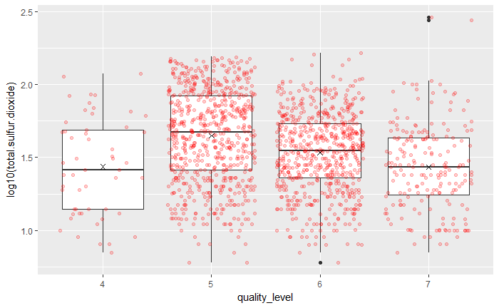